# Quick start to using derfinder

L Collado-Torres

11 November 2015

#### Package version: derfinder 1.5.9

# 1 Quick start to using to *[derfinder](http://bioconductor.org/packages/release/bioc/html/derfinder.html)*

# 2 Introduction

*[derfinder](http://bioconductor.org/packages/release/bioc/html/derfinder.html)* is an R package that implements the DER Finder approach ([Frazee, Sabunciyan, Hansen, Irizarry, et al., 2014](http://biostatistics.oxfordjournals.org/content/15/3/413.long)) for RNA-seq data. Briefly, this approach is an alternative to feature-counting and transcript assembly. The basic idea is to identify contiguous base-pairs in the genome that present differential expression signal. These base-pairs are grouped into _d_ifferentially _e_xpressed _r_regions (DERs). This approach is annotation-agnostic which is a feature you might be interested in. In particular, *[derfinder](http://bioconductor.org/packages/release/bioc/html/derfinder.html)* contains functions that allow you to identify DERs via two alternative methods. You can find more details on the full derfinder users guide.

# 3 Basics

## 3.1 Install *[derfinder](http://bioconductor.org/packages/release/bioc/html/derfinder.html)*

`R` is an open-source statistical environment which can be easily modified to enhance its functionality via packages. *[derfinder](http://bioconductor.org/packages/release/bioc/html/derfinder.html)* is a `R` package available via the [Bioconductor](http://bioconductor/packages/derfinder) repository for packages. `R` can be installed on any operating system from [CRAN](https://cran.r-project.org/) after which you can install *[derfinder](http://bioconductor.org/packages/release/bioc/html/derfinder.html)* by using the following commands in your `R` session:

```r
## try http:// if https:// URLs are not supported
source("https://bioconductor.org/biocLite.R")
biocLite("derfinder")
```

## 3.2 Required knowledge

*[derfinder](http://bioconductor.org/packages/release/bioc/html/derfinder.html)* is based on many other packages and in particular in those that have implemented the infrastructure needed for dealing with RNA-seq data. That is, packages like *[Rsamtools](http://bioconductor.org/packages/release/bioc/html/Rsamtools.html)*, *[GenomicAlignments](http://bioconductor.org/packages/release/bioc/html/GenomicAlignments.html)* and *[rtracklayer](http://bioconductor.org/packages/release/bioc/html/rtracklayer.html)* that allow you to import the data. A *[derfinder](http://bioconductor.org/packages/release/bioc/html/derfinder.html)* user is not expected to deal with those packages directly but will need to be familiar with *[GenomicRanges](http://bioconductor.org/packages/release/bioc/html/GenomicRanges.html)* to understand the results *[derfinder](http://bioconductor.org/packages/release/bioc/html/derfinder.html)* generates. It might also prove to be highly beneficial to check the *[BiocParallel](http://bioconductor.org/packages/release/bioc/html/BiocParallel.html)* package for performing parallel computations.

If you are asking yourself the question “Where do I start using Bioconductor?” you might be interested in [this blog post](http://lcolladotor.github.io/2014/10/16/startBioC/#.VkOKbq6rRuU).

## 3.3 Asking for help

As package developers, we try to explain clearly how to use our packages and in which order to use the functions. But `R` and `Bioconductor` have a steep learning curve so it is critical to learn where to ask for help. The blog post quoted above mentions some but we would like to highlight the [Bioconductor support site](https://support.bioconductor.org/) as the main resource for getting help. Other alternatives are available such as creating GitHub issues and tweeting. However, please note that if you want to receive help you should adhere to the [posting guidlines](http://www.bioconductor.org/help/support/posting-guide/). It is particularly critical that you provide a small reproducible example and your session information so package developers can track down the source of the error.

We would like to highlight the *[derfinder](http://bioconductor.org/packages/release/bioc/html/derfinder.html)* user [Jessica Hekman](https://support.bioconductor.org/u/6877/). She has used *[derfinder](http://bioconductor.org/packages/release/bioc/html/derfinder.html)* with non-human data, and in the process of doing so discovered some small bugs or sections of the documentation that were not clear.

## 3.4 Citing *[derfinder](http://bioconductor.org/packages/release/bioc/html/derfinder.html)*

We hope that *[derfinder](http://bioconductor.org/packages/release/bioc/html/derfinder.html)* will be useful for your research. Please use the following information to cite the package and the overall approach. Thank you!

```r
## Citation info
citation('derfinder')
```

```
##
## Collado-Torres L, Frazee AC, Love MI, Irizarry RA, Jaffe AE and
## Leek JT (2015). "derfinder: Software for annotation-agnostic
## RNA-seq differential expression analysis." _bioRxiv_. <URL:
## http://doi.org/10.1101/015370>, <URL:
## http://www.biorxiv.org/content/early/2015/02/19/015370.abstract>.
##
## Frazee AC, Sabunciyan S, Hansen KD, Irizarry RA and Leek JT
## (2014). "Differential expression analysis of RNA-seq data at
## single-base resolution." _Biostatistics_, *15 (3)*, pp. 413-426.
## <URL: http://doi.org/10.1093/biostatistics/kxt053>, <URL:
## http://biostatistics.oxfordjournals.org/content/15/3/413.long>.
```

# 4 Sample DER Finder analysis

This is a brief overview of what a DER Finder analysis looks like. In particular, here we will be identifying expressed-regions (ERs) without relying on annotation. Next, we’ll identify candidate differentially expressed regions (DERs). Finally, we’ll compare the DERs with known annotation features.

We first load the required packages.

```r
## Load libraries
library('derfinder')
library('derfinderData')
library('GenomicRanges')
```

Next, we need to locate the chromosome 21 coverage files for a set of 12 samples. These samples are a small subset from the *BrainSpan Atlas of the Human Brain* ([BrainSpan, 2011](http://developinghumanbrain.org)) publicly available data. The function `rawFiles()` helps us in locating these files.

```r
## Determine the files to use and fix the names
files <- rawFiles(system.file('extdata', 'AMY', package = 'derfinderData'), samplepatt = 'bw', fileterm = NULL)
names(files) <- gsub('.bw', '', names(files))
```

Next, we can load the full coverage data into memory using the `fullCoverage()` function.

```r
## Load the data from disk
fullCov <- fullCoverage(files = files, chrs = 'chr21', verbose = FALSE)
```

Now that we have the data, we can identify expressed-regions (ERs) by using a cutoff of 30 on the base-level mean coverage from these 12 samples. Once the regions have been identified, we can calculate a coverage matrix with one row per ER and one column per sample (12 in this case). For doing this calculation we need to know the length of the sequence reads, which in this study were 76 bp long.

```r
## Use regionMatrix()
regionMat <- regionMatrix(fullCov, cutoff = 30, L = 76, verbose = FALSE)
```

`regionMatrix()` returns a list of elements, each with three pieces of output. The actual ERs are arranged in a `GRanges` object named `regions`.

```r
## regions output
regionMat$chr21$regions
```

```
## GRanges object with 45 ranges and 6 metadata columns:
##       seqnames               ranges strand   |            value
##          <Rle>            <IRanges>  <Rle>   |        <numeric>
##     1    chr21 [ 9827018,  9827582]      *   | 313.671741938907
##     2    chr21 [15457301, 15457438]      *   | 215.084607424943
##     3    chr21 [20230140, 20230192]      *   | 38.8325471608144
##     4    chr21 [20230445, 20230505]      *   | 41.3245082031834
##     5    chr21 [27253318, 27253543]      *   | 34.9131305372469
##   ...      ...                  ...    ... ...              ...
##    41    chr21 [33039644, 33039688]      *   | 34.4705371008979
##    42    chr21 [33040784, 33040798]      *   |  32.134222178989
##    43    chr21 [33040890, 33040890]      *   | 30.0925002098083
##    44    chr21 [33040900, 33040901]      *   | 30.1208333174388
##    45    chr21 [48019401, 48019414]      *   | 31.1489284609755
##                   area indexStart  indexEnd cluster clusterL
##              <numeric>  <integer> <integer>   <Rle>    <Rle>
##     1 177224.534195483          1       565       1      565
##     2 29681.6758246422        566       703       2      138
##     3 2058.12499952316        704       756       3      366
##     4 2520.79500039419        757       817       3      366
##     5  7890.3675014178        818      1043       4      765
##   ...              ...        ...       ...     ...      ...
##    41 1551.17416954041       2180      2224      17       45
##    42 482.013332684835       2225      2239      18      118
##    43 30.0925002098083       2240      2240      18      118
##    44 60.2416666348775       2241      2242      18      118
##    45 436.084998453657       2243      2256      19       14
##   -------
##   seqinfo: 1 sequence from an unspecified genome
```

`bpCoverage` is the base level coverage list which can then be used for plotting.

```r
## Base-level coverage matrices for each of the regions
## Useful for plotting
lapply(regionMat$chr21$bpCoverage[1:2], head, n = 2)
```

```
## $`1`
##   HSB113 HSB123 HSB126 HSB130 HSB135 HSB136 HSB145 HSB153 HSB159 HSB178
## 1  93.20   3.32  28.22   5.62 185.17  98.34   5.88  16.71   3.52  15.71
## 2 124.76   7.25  63.68  11.32 374.85 199.28  10.39  30.53   5.83  29.35
##   HSB92 HSB97
## 1 47.40 36.54
## 2 65.04 51.42
##
## $`2`
##     HSB113 HSB123 HSB126 HSB130 HSB135 HSB136 HSB145 HSB153 HSB159 HSB178
## 566  45.59   7.94  15.92  34.75 141.61 104.21  19.87  38.61   4.97   23.2
## 567  45.59   7.94  15.92  35.15 141.64 104.30  19.87  38.65   4.97   23.2
##     HSB92 HSB97
## 566 13.95 22.21
## 567 13.95 22.21
```

```r
## Check dimensions. First region is 565 long, second one is 138 bp long.
## The columns match the number of samples (12 in this case).
lapply(regionMat$chr21$bpCoverage[1:2], dim)
```

```
## $`1`
## [1] 565  12
##
## $`2`
## [1] 138  12
```

The end result of the coverage matrix is shown below. Note that the coverage has been adjusted for read length. Because reads might not fully align inside a given region, the numbers are generally not integers but can be rounded if needed.

```r
## Dimensions of the coverage matrix
dim(regionMat$chr21$coverageMatrix)
```

```
## [1] 45 12
```

```r
## Coverage for each region. This matrix can then be used with limma or other pkgs
head(regionMat$chr21$coverageMatrix)
```

```
##         HSB113     HSB123      HSB126      HSB130      HSB135      HSB136
## 1 3653.1093346 277.072106 1397.068687 1106.722895 8987.460401 5570.221054
## 2  333.3740816  99.987237  463.909476  267.354342 1198.713552 1162.313418
## 3   35.3828948  20.153553   30.725394   23.483947   16.786842   17.168947
## 4   42.3398681  29.931579   41.094474   24.724736   32.634080   19.309606
## 5   77.7402631 168.939342  115.059342  171.861974  180.638684   93.503158
## 6    0.7988158   1.770263    1.473421    2.231053    1.697368    1.007895
##        HSB145       HSB153     HSB159      HSB178       HSB92        HSB97
## 1 1330.158818 1461.2986829 297.939342 1407.288552 1168.519079 1325.9622371
## 2  257.114210  313.8513139  67.940131  193.695657  127.543553  200.7834228
## 3   22.895921   52.8756585  28.145395   33.127368   23.758816   20.4623685
## 4   33.802632   51.6146040  31.244343   33.576974   29.546183   28.2011836
## 5   90.950526   36.3046051  78.069605   97.151316  100.085790   35.5428946
## 6    1.171316    0.4221053   1.000132    1.139079    1.136447    0.3956579
```

We can then use the coverage matrix and packages such as *[limma](http://bioconductor.org/packages/release/bioc/html/limma.html)*, *[DESeq2](http://bioconductor.org/packages/release/bioc/html/DESeq2.html)* or *[edgeR](http://bioconductor.org/packages/release/bioc/html/edgeR.html)* to identify which ERs are differentially expressed. Here we’ll use *[DESeq2](http://bioconductor.org/packages/release/bioc/html/DESeq2.html)* for which we need some phenotype data.

```r
## Get pheno table
pheno <- subset(brainspanPheno, structure_acronym == 'AMY')
```

Now we can identify the DERs using a rounded version of the coverage matrix.

```r
## Required
library('DESeq2')
## Round matrix
counts <- round(regionMat$chr21$coverageMatrix)

## Round matrix and specify design
dse <- DESeqDataSetFromMatrix(counts, pheno, ~ group + gender)
## Perform DE analysis
dse <- DESeq(dse, test = 'LRT', reduced = ~ gender, fitType = 'local')
## Extract results
mcols(regionMat$chr21$regions) <- c(mcols(regionMat$chr21$regions), results(dse))

## Save info in an object with a shorter name
ers <- regionMat$chr21$regions
ers
```

```
## GRanges object with 45 ranges and 12 metadata columns:
##       seqnames               ranges strand   |            value
##          <Rle>            <IRanges>  <Rle>   |        <numeric>
##     1    chr21 [ 9827018,  9827582]      *   | 313.671741938907
##     2    chr21 [15457301, 15457438]      *   | 215.084607424943
##     3    chr21 [20230140, 20230192]      *   | 38.8325471608144
##     4    chr21 [20230445, 20230505]      *   | 41.3245082031834
##     5    chr21 [27253318, 27253543]      *   | 34.9131305372469
##   ...      ...                  ...    ... ...              ...
##    41    chr21 [33039644, 33039688]      *   | 34.4705371008979
##    42    chr21 [33040784, 33040798]      *   |  32.134222178989
##    43    chr21 [33040890, 33040890]      *   | 30.0925002098083
##    44    chr21 [33040900, 33040901]      *   | 30.1208333174388
##    45    chr21 [48019401, 48019414]      *   | 31.1489284609755
##                   area indexStart  indexEnd cluster clusterL
```

[output cut: 40 more lines]

We can then compare the DERs against known annotation to see which DERs overlap known exons, introns, or intergenic regions. A way to visualize this information is via a Venn diagram which we can create using `vennRegions()` from the *[derfinderPlot](http://bioconductor.org/packages/release/bioc/html/derfinderPlot.html)* package.

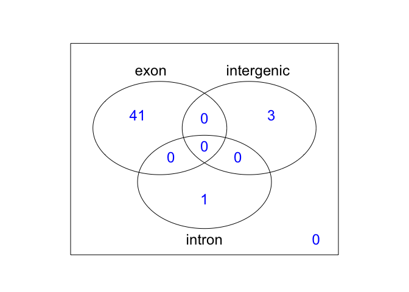

```r
## Find overlaps between regions and summarized genomic annotation
annoRegs <- annotateRegions(ers, genomicState$fullGenome, verbose = FALSE)

library('derfinderPlot')
venn <- vennRegions(annoRegs, counts.col = 'blue')
```

We can also identify the nearest annotated feature. In this case, we’ll look for the nearest known gene from the UCSC hg19 annotation.

```r
## Load database of interest
library('TxDb.Hsapiens.UCSC.hg19.knownGene')
txdb <- keepSeqlevels(TxDb.Hsapiens.UCSC.hg19.knownGene, 'chr21')

## Find nearest feature
library('bumphunter')
```

```
## locfit 1.5-9.1    2013-03-22
```

```r
genes <- annotateTranscripts(txdb)
```

```
## No annotationPackage supplied. Trying org.Hs.eg.db.
##
## Getting TSS and TSE.
## Getting CSS and CSE.
## Getting exons.
## Annotating genes.
```

```r
annotation <- matchGenes(ers, subject = genes)

## Extract the region coverage
regionCov <- regionMat$chr21$bpCoverage
```

We can broadly visualize the nearest feature for our ERs using the function `plotOverview()`.

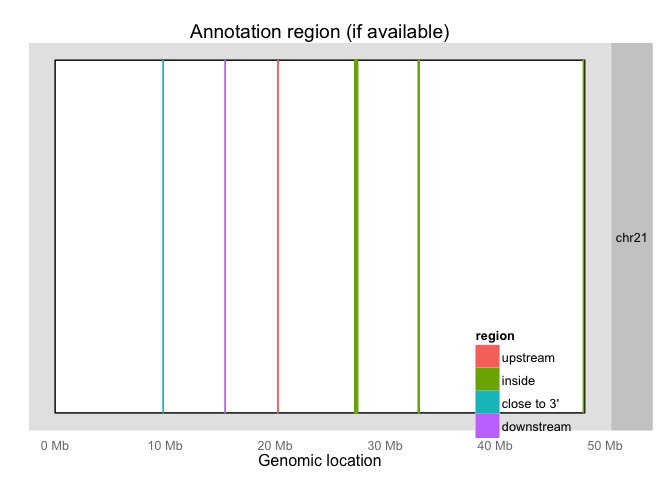

```r
## Overview of the candidate DERs in the genome
plotOverview(regions = ers, annotation = annotation, type = 'annotation')
```

Or we can check the base-level coverage information for some of our DERs. In this example we do so for the first 5 ERs.

```
## 2015-11-11 18:47:17 plotRegionCoverage: extracting Tx info
## 2015-11-11 18:47:21 plotRegionCoverage: getting Tx plot info
```

[figure not shown]

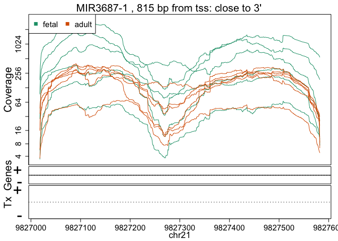

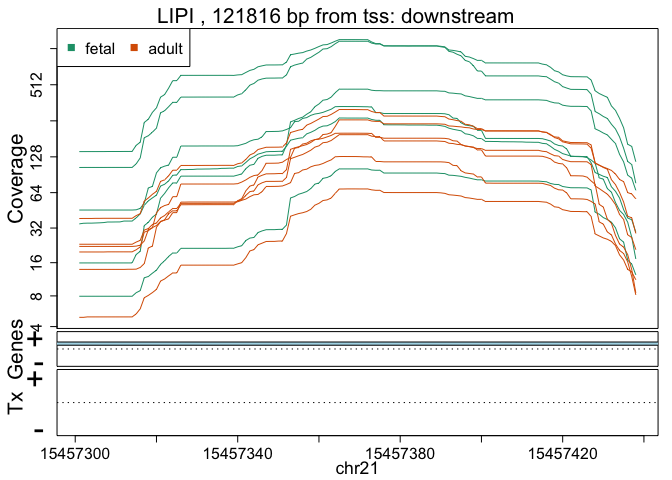

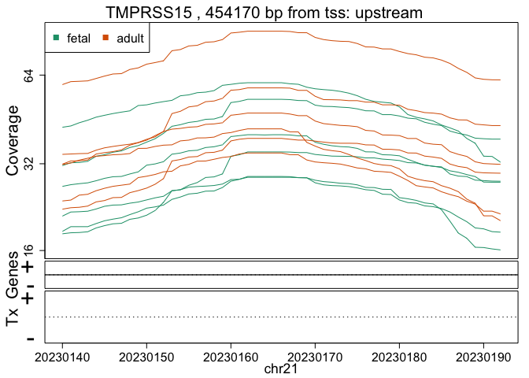

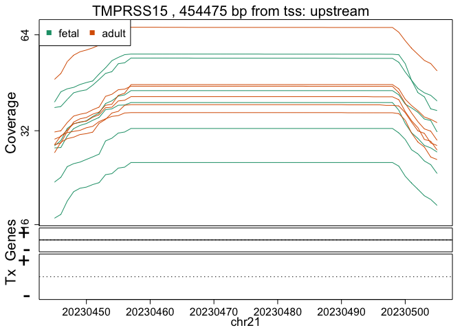

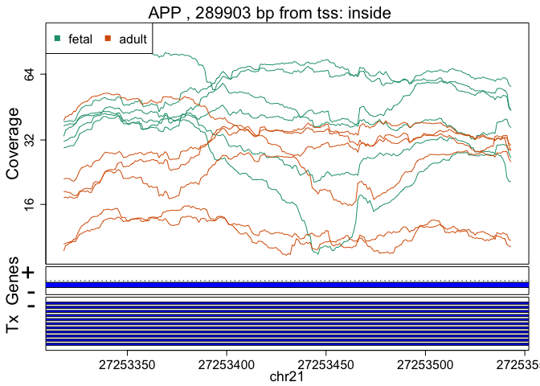

```r
plotRegionCoverage(regions = ers, regionCoverage = regionCov,
    groupInfo = pheno$group, nearestAnnotation = annotation,
    annotatedRegions = annoRegs, whichRegions = seq_len(5), txdb = txdb, scalefac = 1,
    ask = FALSE)
```

You can then use the *[regionReport](http://bioconductor.org/packages/release/bioc/html/regionReport.html)* package to generate interactive HTML reports exploring the results.

If you are interested in using *[derfinder](http://bioconductor.org/packages/release/bioc/html/derfinder.html)* we recommend checking the derfinder users guide and good luck with your analyses!

# 5 Reproducibility

This package was made possible thanks to:

- R ([R Core Team, 2015](https://www.R-project.org/))
- *[AnnotationDbi](http://bioconductor.org/packages/release/bioc/html/AnnotationDbi.html)* (Pages, Carlson, Falcon, and Li, 2015)
- *[BiocParallel](http://bioconductor.org/packages/release/bioc/html/BiocParallel.html)* (Morgan, Obenchain, Lang, and Thompson, 2015)
- *[bumphunter](http://bioconductor.org/packages/release/bioc/html/bumphunter.html)* ([Jaffe, Murakami, Lee, Leek, et al., 2012](http://dx.doi.org/10.1093/ije/dyr238)) and (Jaffe, E, Murakami, Peter, et al., 2012)
- *[derfinderHelper](http://bioconductor.org/packages/release/bioc/html/derfinderHelper.html)*
- *[GenomeInfoDb](http://bioconductor.org/packages/release/bioc/html/GenomeInfoDb.html)* (Arora, Morgan, Carlson, and Pages, 2015)
- *[GenomicAlignments](http://bioconductor.org/packages/release/bioc/html/GenomicAlignments.html)* ([Lawrence, Huber, Pagès, Aboyoun, et al., 2013](http://www.ploscompbiol.org/article/info%3Adoi%2F10.1371%2Fjournal.pcbi.1003118))
- *[GenomicFeatures](http://bioconductor.org/packages/release/bioc/html/GenomicFeatures.html)* ([Lawrence, Huber, Pagès, Aboyoun, et al., 2013](http://www.ploscompbiol.org/article/info%3Adoi%2F10.1371%2Fjournal.pcbi.1003118))
- *[GenomicFiles](http://bioconductor.org/packages/release/bioc/html/GenomicFiles.html)* (Obenchain, Love, and Morgan, 2015)
- *[GenomicRanges](http://bioconductor.org/packages/release/bioc/html/GenomicRanges.html)* ([Lawrence, Huber, Pagès, Aboyoun, et al., 2013](http://www.ploscompbiol.org/article/info%3Adoi%2F10.1371%2Fjournal.pcbi.1003118))
- *[Hmisc](http://cran.fhcrc.org/web/packages/Hmisc/index.html)* ([Jr, with contributions from Charles Dupont, and many others., 2015](http://CRAN.R-project.org/package=Hmisc))
- *[IRanges](http://bioconductor.org/packages/release/bioc/html/IRanges.html)* ([Lawrence, Huber, Pagès, Aboyoun, et al., 2013](http://www.ploscompbiol.org/article/info%3Adoi%2F10.1371%2Fjournal.pcbi.1003118))
- *[qvalue](http://bioconductor.org/packages/release/bioc/html/qvalue.html)* (with contributions from Andrew J. Bass, Dabney, and Robinson, 2015)
- *[Rsamtools](http://bioconductor.org/packages/release/bioc/html/Rsamtools.html)* ([Morgan, Pagès, Obenchain, and Hayden, 2015](http://bioconductor.org/packages/release/bioc/html/Rsamtools.html))
- *[rtracklayer](http://bioconductor.org/packages/release/bioc/html/rtracklayer.html)* ([Lawrence, Gentleman, and Carey, 2009](http://bioinformatics.oxfordjournals.org/content/25/14/1841.abstract))
- *[S4Vectors](http://bioconductor.org/packages/release/bioc/html/S4Vectors.html)* (Pages, Lawrence, and Aboyoun, 2015)
- *[biovizBase](http://bioconductor.org/packages/release/bioc/html/biovizBase.html)* (Yin, Lawrence, and Cook, 2015)
- *[derfinderData](http://bioconductor.org/packages/release/data/experiment/html/derfinderData.html)* ([Collado-Torres, Jaffe, and Leek, 2015](https://github.com/lcolladotor/derfinderData))
- *[devtools](http://cran.fhcrc.org/web/packages/devtools/index.html)* ([Wickham and Chang, 2015](http://CRAN.R-project.org/package=devtools))
- *[ggplot2](http://cran.fhcrc.org/web/packages/ggplot2/index.html)* ([Wickham, 2009](http://had.co.nz/ggplot2/book))
- *[knitcitations](http://cran.fhcrc.org/web/packages/knitcitations/index.html)* ([Boettiger, 2015](http://CRAN.R-project.org/package=knitcitations))
- *[knitr](http://cran.fhcrc.org/web/packages/knitr/index.html)* ([Xie, 2014](http://www.crcpress.com/product/isbn/9781466561595))
- *[BiocStyle](http://bioconductor.org/packages/release/bioc/html/BiocStyle.html)* ([Morgan, Oleś, and Huber, 2015](https://github.com/Bioconductor/BiocStyle))
- *[rmarkdown](http://cran.fhcrc.org/web/packages/rmarkdown/index.html)* ([Allaire, Cheng, Xie, McPherson, et al., 2015](http://CRAN.R-project.org/package=rmarkdown))
- *[testthat](http://cran.fhcrc.org/web/packages/testthat/index.html)* ([Wickham, 2011](http://journal.r-project.org/archive/2011-1/RJournal_2011-1_Wickham.pdf))
- *[TxDb.Hsapiens.UCSC.hg19.knownGene](http://bioconductor.org/packages/release/data/annotation/html/TxDb.Hsapiens.UCSC.hg19.knownGene.html)* (Carlson and Maintainer, 2015)

Code for creating the vignette

```r
## Create the vignette
library('rmarkdown')
system.time(render('quickstart-derfinder.Rmd', 'BiocStyle::html_document'))

## Extract the R code
library('knitr')
knit('quickstart-derfinder.Rmd', tangle = TRUE)
```

```r
## Clean up
file.remove('quickstartRef.bib')
```

```
## [1] TRUE
```

Date the vignette was generated.

```
## [1] "2015-11-11 18:47:23 EST"
```

Wallclock time spent generating the vignette.

```
## Time difference of 1.007 mins
```

[session information not shown]

```
##  setting  value
##  version  R version 3.2.2 (2015-08-14)
##  system   x86_64, darwin13.4.0
##  ui       X11
##  language (EN)
##  collate  en_US.UTF-8
##  tz       America/New_York
##  date     2015-11-11
```

```
## Packages ---------------------------------------------------------------------------------------------------------------
```

```
##  package                           * version     date       source
##  acepack                             1.3-3.3     2014-11-24 CRAN (R 3.2.0)
##  annotate                            1.48.0      2015-10-14 Bioconductor
##  AnnotationDbi                     * 1.32.0      2015-10-14 Bioconductor
##  bibtex                              0.4.0       2014-12-31 CRAN (R 3.2.0)
##  Biobase                           * 2.30.0      2015-10-14 Bioconductor
##  BiocGenerics                      * 0.16.1      2015-11-06 Bioconductor
##  BiocInstaller                       1.20.0      2015-10-14 Bioconductor
##  BiocParallel                        1.4.0       2015-10-14 Bioconductor
##  BiocStyle                         * 1.8.0       2015-10-14 Bioconductor
##  biomaRt                             2.26.0      2015-10-14 Bioconductor
##  Biostrings                          2.38.0      2015-10-14 Bioconductor
##  biovizBase                          1.18.0      2015-10-14 Bioconductor
##  bitops                              1.0-6       2013-08-17 CRAN (R 3.2.0)
##  BSgenome                            1.38.0      2015-10-14 Bioconductor
##  bumphunter                        * 1.10.0      2015-10-14 Bioconductor
##  cluster                             2.0.3       2015-07-21 CRAN (R 3.2.2)
##  codetools                           0.2-14      2015-07-15 CRAN (R 3.2.2)
##  colorspace                          1.2-6       2015-03-11 CRAN (R 3.2.0)
##  DBI                               * 0.3.1       2014-09-24 CRAN (R 3.2.0)
##  derfinder                         * 1.5.9       2015-11-11 Bioconductor
##  derfinderData                     * 0.104.0     2015-10-15 Bioconductor
##  derfinderHelper                     1.4.1       2015-11-03 Bioconductor
##  derfinderPlot                     * 1.4.0       2015-10-14 Bioconductor
##  DESeq2                            * 1.10.0      2015-10-14 Bioconductor
##  devtools                          * 1.9.1       2015-09-11 CRAN (R 3.2.0)
##  dichromat                           2.0-0       2013-01-24 CRAN (R 3.2.0)
##  digest                              0.6.8       2014-12-31 CRAN (R 3.2.0)
##  doRNG                               1.6         2014-03-07 CRAN (R 3.2.0)
##  evaluate                            0.8         2015-09-18 CRAN (R 3.2.0)
##  foreach                           * 1.4.3       2015-10-13 CRAN (R 3.2.0)
##  foreign                             0.8-66      2015-08-19 CRAN (R 3.2.0)
##  formatR                             1.2.1       2015-09-18 CRAN (R 3.2.0)
##  Formula                             1.2-1       2015-04-07 CRAN (R 3.2.0)
##  futile.logger                       1.4.1       2015-04-20 CRAN (R 3.2.0)
##  futile.options                      1.0.0       2010-04-06 CRAN (R 3.2.0)
##  genefilter                          1.52.0      2015-10-14 Bioconductor
##  geneplotter                         1.48.0      2015-10-14 Bioconductor
##  GenomeInfoDb                      * 1.6.1       2015-11-03 Bioconductor
##  GenomicAlignments                   1.6.1       2015-10-22 Bioconductor
```

[output cut: 51 more lines]

```
##  RSQLite                           * 1.0.0       2014-10-25 CRAN (R 3.2.0)
##  rtracklayer                         1.30.1      2015-10-22 Bioconductor
##  S4Vectors                         * 0.8.1       2015-11-05 Bioconductor
##  scales                              0.3.0       2015-08-25 CRAN (R 3.2.0)
##  stringi                             1.0-1       2015-10-22 CRAN (R 3.2.0)
##  stringr                             1.0.0       2015-04-30 CRAN (R 3.2.0)
##  SummarizedExperiment              * 1.0.1       2015-11-06 Bioconductor
##  survival                            2.38-3      2015-07-02 CRAN (R 3.2.2)
##  TxDb.Hsapiens.UCSC.hg19.knownGene * 3.2.2       2015-10-15 Bioconductor
##  VariantAnnotation                   1.16.2      2015-11-01 Bioconductor
##  XML                                 3.98-1.3    2015-06-30 CRAN (R 3.2.0)
##  xtable                              1.8-0       2015-11-02 CRAN (R 3.2.0)
##  XVector                             0.10.0      2015-10-14 Bioconductor
##  yaml                                2.1.13      2014-06-12 CRAN (R 3.2.0)
##  zlibbioc                            1.16.0      2015-10-14 Bioconductor
```

# 6 Bibliography

This vignette was generated using *[BiocStyle](http://bioconductor.org/packages/release/bioc/html/BiocStyle.html)* ([Morgan, Oleś, and Huber, 2015](https://github.com/Bioconductor/BiocStyle)) with *[knitr](http://cran.fhcrc.org/web/packages/knitr/index.html)* ([Xie, 2014](http://www.crcpress.com/product/isbn/9781466561595)) and *[rmarkdown](http://cran.fhcrc.org/web/packages/rmarkdown/index.html)* ([Allaire, Cheng, Xie, McPherson, et al., 2015](http://CRAN.R-project.org/package=rmarkdown)) running behind the scenes.

Citations made with *[knitcitations](http://cran.fhcrc.org/web/packages/knitcitations/index.html)* ([Boettiger, 2015](http://CRAN.R-project.org/package=knitcitations)).

[1] J. Allaire, J. Cheng, Y. Xie, J. McPherson, et al. *rmarkdown: Dynamic Documents for R*. R package version 0.8.1. 2015. URL: http://CRAN.R-project.org/package=rmarkdown.

[2] J. D. S. with contributions from Andrew J. Bass, A. Dabney and D. Robinson. *qvalue: Q-value estimation for false discovery rate control*. R package version 2.2.0. 2015. URL: http://qvalue.princeton.edu/, http://github.com/jdstorey/qvalue.

[3] S. Arora, M. Morgan, M. Carlson and H. Pages. *GenomeInfoDb: Utilities for manipulating chromosome and other ‘seqname’ identifiers*. R package version 1.6.1. 2015.

[4] C. Boettiger. *knitcitations: Citations for Knitr Markdown Files*. R package version 1.0.6. 2015. URL: http://CRAN.R-project.org/package=knitcitations.

[5] BrainSpan. “Atlas of the Developing Human Brain [Internet]. Funded by ARRA Awards 1RC2MH089921-01, 1RC2MH090047-01, and 1RC2MH089929-01.” 2011. URL: http://developinghumanbrain.org.

[6] M. Carlson and B. P. Maintainer. *TxDb.Hsapiens.UCSC.hg19.knownGene: Annotation package for TxDb object(s)*. R package version 3.2.2. 2015.

[7] L. Collado-Torres, A. Jaffe and J. Leek. *derfinderData: Processed BigWigs from BrainSpan for examples*. R package version 0.104.0. 2015. URL: https://github.com/lcolladotor/derfinderData.

[8] A. C. Frazee, S. Sabunciyan, K. D. Hansen, R. A. Irizarry, et al. “Differential expression analysis of RNA-seq data at single-base resolution”. In: *Biostatistics* 15 (3) (2014), pp. 413-426. DOI: 10.1093/biostatistics/kxt053. URL: http://biostatistics.oxfordjournals.org/content/15/3/413.long.

[9] A. E. Jaffe, P. Murakami, H. Lee, J. T. Leek, et al. “Bump hunting to identify differentially methylated regions in epigenetic epidemiology studies”. In: *International journal of epidemiology* 41.1 (2012), pp. 200–209. DOI: 10.1093/ije/dyr238.

[10] Jaffe, A. E, Murakami, Peter, et al. “Bump hunting to identify differentially methylated regions in epigenetic epidemiology studies”. In: *International Journal of Epidemiology* (2012).

[11] F. E. H. Jr, with contributions from Charles Dupont and many others. *Hmisc: Harrell Miscellaneous*. R package version 3.17-0. 2015. URL: http://CRAN.R-project.org/package=Hmisc.

[12] M. Lawrence, R. Gentleman and V. Carey. “rtracklayer: an R package for interfacing with genome browsers”. In: *Bioinformatics* 25 (2009), pp. 1841-1842. DOI: 10.1093/bioinformatics/btp328. URL: http://bioinformatics.oxfordjournals.org/content/25/14/1841.abstract.

[13] M. Lawrence, W. Huber, H. Pagès, P. Aboyoun, et al. “Software for Computing and Annotating Genomic Ranges”. In: *PLoS Computational Biology* 9 (8 2013). DOI: 10.1371/journal.pcbi.1003118. URL: http://www.ploscompbiol.org/article/info%3Adoi%2F10.1371%2Fjournal.pcbi.1003118}.

[14] M. Morgan, V. Obenchain, M. Lang and R. Thompson. *BiocParallel: Bioconductor facilities for parallel evaluation*. R package version 1.4.0. 2015.

[15] M. Morgan, A. Oleś and W. Huber. *BiocStyle: Standard styles for vignettes and other Bioconductor documents*. R package version 1.8.0. 2015. URL: https://github.com/Bioconductor/BiocStyle.

[16] M. Morgan, H. Pagès, V. Obenchain and N. Hayden. *Rsamtools: Binary alignment (BAM), FASTA, variant call (BCF), and tabix file import*. R package version 1.22.0. 2015. URL: http://bioconductor.org/packages/release/bioc/html/Rsamtools.html.

[17] V. Obenchain, M. Love and M. Morgan. *GenomicFiles: Distributed computing by file or by range*. R package version 1.6.0. 2015.

[18] H. Pages, M. Carlson, S. Falcon and N. Li. *AnnotationDbi: Annotation Database Interface*. R package version 1.32.0. 2015.

[19] H. Pages, M. Lawrence and P. Aboyoun. *S4Vectors: S4 implementation of vectors and lists*. R package version 0.8.1. 2015.

[20] R Core Team. *R: A Language and Environment for Statistical Computing*. R Foundation for Statistical Computing. Vienna, Austria, 2015. URL: https://www.R-project.org/.

[21] H. Wickham. *ggplot2: elegant graphics for data analysis*. Springer New York, 2009. ISBN: 978-0-387-98140-6. URL: http://had.co.nz/ggplot2/book.

[22] H. Wickham. “testthat: Get Started with Testing”. In: *The R Journal* 3 (2011), pp. 5–10. URL: http://journal.r-project.org/archive/2011-1/RJournal_2011-1_Wickham.pdf.

[23] H. Wickham and W. Chang. *devtools: Tools to Make Developing R Packages Easier*. R package version 1.9.1. 2015. URL: http://CRAN.R-project.org/package=devtools.

[24] Y. Xie. “knitr: A Comprehensive Tool for Reproducible Research in R”. In: *Implementing Reproducible Computational Research*. Ed. by V. Stodden, F. Leisch and R. D. Peng. ISBN 978-1466561595. Chapman and Hall/CRC, 2014. URL: http://www.crcpress.com/product/isbn/9781466561595.

[25] T. Yin, M. Lawrence and D. Cook. *biovizBase: Basic graphic utilities for visualization of genomic data.* R package version 1.18.0. 2015.